# COMPSCIX 415.2 Homework 4

Dai_Zhechen

2/22/2019

```r
library(mdsr)
library(tidyverse)
library(nycflights13)
```

## Exercises 5.6.7

### (2)

```r
not_cancelled <-
  flights %>%
  filter(!is.na(dep_delay), !is.na(arr_delay))
```

```r
not_cancelled %>% count(dest)
```

```
## # A tibble: 104 x 2
##    dest      n
##    <chr> <int>
##  1 ABQ     254
##  2 ACK     264
##  3 ALB     418
##  4 ANC       8
##  5 ATL   16837
##  6 AUS    2411
##  7 AVL     261
##  8 BDL     412
##  9 BGR     358
## 10 BHM     269
## # … with 94 more rows
```

#### without using `count()`

```r
not_cancelled %>%
  group_by(dest) %>%
  summarise(n = n())
```

```
## # A tibble: 104 x 2
##    dest      n
##    <chr> <int>
##  1 ABQ     254
##  2 ACK     264
##  3 ALB     418
##  4 ANC       8
##  5 ATL   16837
##  6 AUS    2411
##  7 AVL     261
##  8 BDL     412
##  9 BGR     358
## 10 BHM     269
## # … with 94 more rows
```

```r
not_cancelled %>% count(tailnum, wt = distance)
```

```
## # A tibble: 4,037 x 2
##    tailnum      n
##    <chr>    <dbl>
##  1 D942DN    3418
##  2 N0EGMQ  239143
##  3 N10156  109664
##  4 N102UW   25722
##  5 N103US   24619
##  6 N104UW   24616
##  7 N10575  139903
##  8 N105UW   23618
##  9 N107US   21677
## 10 N108UW   32070
## # … with 4,027 more rows
```

#### without using `count()`

```r
not_cancelled %>%
  group_by(tailnum) %>%
  summarize(n = sum(distance))
```

```
## # A tibble: 4,037 x 2
##    tailnum      n
##    <chr>    <dbl>
##  1 D942DN    3418
##  2 N0EGMQ  239143
##  3 N10156  109664
##  4 N102UW   25722
##  5 N103US   24619
##  6 N104UW   24616
##  7 N10575  139903
##  8 N105UW   23618
##  9 N107US   21677
## 10 N108UW   32070
## # … with 4,027 more rows
```

### (4)

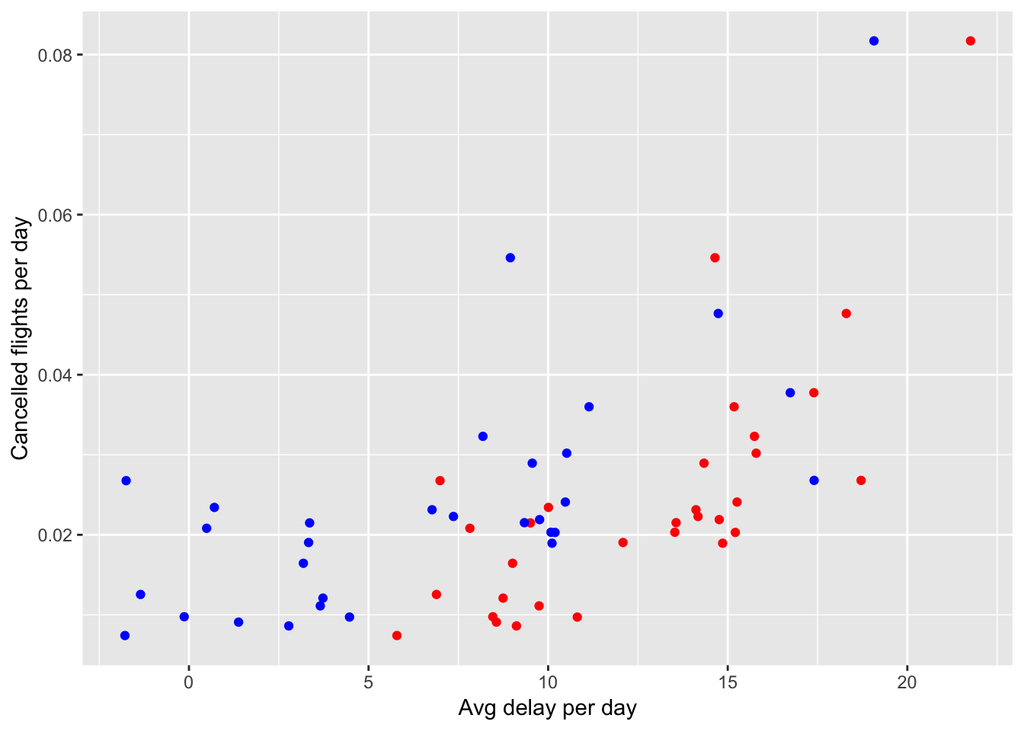

```r
flights %>%
  group_by(day) %>%
  summarise(cancelled = mean(is.na(dep_delay)),
            mean_dep = mean(dep_delay, na.rm = T),
            mean_arr = mean(arr_delay, na.rm = T)) %>%
  ggplot(aes(y = cancelled)) +
  geom_point(aes(x = mean_dep), colour = "red") +
  geom_point(aes(x = mean_arr), colour = "blue") +
  labs(x = "Avg delay per day", y = "Cancelled flights per day")
```

It looks like they have the positive relationship with each other, the higher the average delay per day, the higher the cancelled flights per day.

### (6)

You can use the `sort` to sort the cases based on the `count()`.

### (5) Extra Credit

```r
flights %>%
  group_by(carrier) %>%
  summarise(dep_max = max(dep_delay, na.rm = T),
            arr_max = max(arr_delay, na.rm = T)) %>%
  arrange(desc(dep_max, arr_max)) %>%
  filter(1:n() == 1)
```

```
## # A tibble: 1 x 3
##   carrier dep_max arr_max
##   <chr>     <dbl>   <dbl>
## 1 HA         1301    1272
```

Carrier `HA`

## Exercises 10.5

### (1)

```r
data("mtcars")
class(mtcars)
```

```
## [1] "data.frame"
```

```r
mtcars <- as_tibble(mtcars)
class(mtcars)
```

```
## [1] "tbl_df"     "tbl"        "data.frame"
```

Get the `class()` of object and see whether it has `tbl_df` and `tbl`.

### (2)

```r
df <- data.frame(abc = 1, xyz = "a")
df$x
```

```
## [1] a
## Levels: a
```

```r
df[, "xyz"]
```

```
## [1] a
## Levels: a
```

```r
df[, c("abc", "xyz")]
```

```
##   abc xyz
## 1   1   a
```

```r
df <- as_tibble(data.frame(abc = 1, xyz = "a"))
df$x
```

[output not shown]

```r
df[, "xyz"]
```

```
## # A tibble: 1 x 1
##   xyz
##   <fct>
## 1 a
```

```r
df[, c("abc", "xyz")]
```

```
## # A tibble: 1 x 2
##     abc xyz
##   <dbl> <fct>
## 1     1 a
```

In some cases, a data frame will returns a different thing.

Tibble will return the same thing, providing consistency.

### (3)

```r
var <- "mpg"
as_tibble(mtcars)[[var]]
```

```
##  [1] 21.0 21.0 22.8 21.4 18.7 18.1 14.3 24.4 22.8 19.2 17.8 16.4 17.3 15.2
## [15] 10.4 10.4 14.7 32.4 30.4 33.9 21.5 15.5 15.2 13.3 19.2 27.3 26.0 30.4
## [29] 15.8 19.7 15.0 21.4
```

### (6)

`options(tibble.width = Inf)` for all columns to be printed (Confused)

## Exercises 12.3.3

### (2)

```r
table4a %>%
  gather("1999", "2000", key = "year", value = "cases")
```

```
## # A tibble: 6 x 3
##   country     year   cases
##   <chr>       <chr>  <int>
## 1 Afghanistan 1999     745
## 2 Brazil      1999   37737
## 3 China       1999  212258
## 4 Afghanistan 2000    2666
## 5 Brazil      2000   80488
## 6 China       2000  213766
```

Because `gather()` can not find the columns’ name

### (3)

```r
people <- tribble(
  ~name,             ~key,    ~value,
  #-----------------|--------|------
  "Phillip Woods",   "age",       45,
  "Phillip Woods",   "height",   186,
  "Phillip Woods",   "age",       50,
  "Jessica Cordero", "age",       37,
  "Jessica Cordero", "height",   156
)
```

```r
people %>%
  mutate(unique_id = c(1, 2, 2, 3, 3)) %>%
  select(unique_id, everything()) %>%
  spread(key, value)
```

```
## # A tibble: 3 x 4
##   unique_id name              age height
##       <dbl> <chr>           <dbl>  <dbl>
## 1         1 Phillip Woods      45     NA
## 2         2 Phillip Woods      50    186
## 3         3 Jessica Cordero    37    156
```

Phillip Woods has two columns of age, it is inpossible for one person, we need to unique them.

### (4)

```r
preg <- tribble(
  ~pregnant, ~male, ~female,
  "yes",     NA,    10,
  "no",      20,    12
)
```

Gather it.

```r
preg %>%
  gather(gender, values, -pregnant)
```

```
## # A tibble: 4 x 3
##   pregnant gender values
##   <chr>    <chr>   <dbl>
## 1 yes      male       NA
## 2 no       male       20
## 3 yes      female     10
## 4 no       female     12
```

## Exercises 12.4.3

### (1)

`extra` If sep is a character vector, this controls what happens when there are too many pieces. There are three valid options:

“warn” (the default): emit a warning and drop extra values.

“drop”: drop any extra values without a warning.

“merge”: only splits at most length(into) times

`fill` If sep is a character vector, this controls what happens when there are not enough pieces. There are three valid options:

“warn” (the default): emit a warning and fill from the right

“right”: fill with missing values on the right

“left”: fill with missing values on the left

```r
tibble(x = c("a,b,c", "d,e,f,g", "h,i,j")) %>%
  separate(x, c("one", "two", "three"))
```

```
## Warning: Expected 3 pieces. Additional pieces discarded in 1 rows [2].
```

```
## # A tibble: 3 x 3
##   one   two   three
##   <chr> <chr> <chr>
## 1 a     b     c
## 2 d     e     f
## 3 h     i     j
```

```r
tibble(x = c("a,b,c", "d,e,f,g", "h,i,j")) %>%
  separate(x, c("one", "two", "three"), extra = "warn")
```

```
## # A tibble: 3 x 3
##   one   two   three
##   <chr> <chr> <chr>
## 1 a     b     c
## 2 d     e     f
## 3 h     i     j
```

```r
tibble(x = c("a,b,c", "d,e,f,g", "h,i,j")) %>%
  separate(x, c("one", "two", "three"), extra = "drop")
```

```
## # A tibble: 3 x 3
##   one   two   three
##   <chr> <chr> <chr>
## 1 a     b     c
## 2 d     e     f
## 3 h     i     j
```

```r
tibble(x = c("a,b,c", "d,e,f,g", "h,i,j")) %>%
  separate(x, c("one", "two", "three"), extra = "merge")
```

```
## # A tibble: 3 x 3
##   one   two   three
##   <chr> <chr> <chr>
## 1 a     b     c
## 2 d     e     f,g
## 3 h     i     j
```

```r
tibble(x = c("a,b,c", "d,e,f,g", "h,i,j")) %>%
  separate(x, c("one", "two", "three", "four"))
```

```
## # A tibble: 3 x 4
##   one   two   three four
##   <chr> <chr> <chr> <chr>
## 1 a     b     c     <NA>
## 2 d     e     f     g
## 3 h     i     j     <NA>
```

```r
tibble(x = c("a,b,c", "d,e,f,g", "h,i,j")) %>%
  separate(x, c("one", "two", "three", "four"), fill = "warn")
```

```
## # A tibble: 3 x 4
##   one   two   three four
##   <chr> <chr> <chr> <chr>
## 1 a     b     c     <NA>
## 2 d     e     f     g
## 3 h     i     j     <NA>
```

```r
tibble(x = c("a,b,c", "d,e,f,g", "h,i,j")) %>%
  separate(x, c("one", "two", "three", "four"), fill = "right")
```

```
## # A tibble: 3 x 4
##   one   two   three four
##   <chr> <chr> <chr> <chr>
## 1 a     b     c     <NA>
## 2 d     e     f     g
## 3 h     i     j     <NA>
```

```r
tibble(x = c("a,b,c", "d,e,f,g", "h,i,j")) %>%
  separate(x, c("one", "two", "three", "four"), fill = "left")
```

```
## # A tibble: 3 x 4
##   one   two   three four
##   <chr> <chr> <chr> <chr>
## 1 <NA>  a     b     c
## 2 d     e     f     g
## 3 <NA>  h     i     j
```

### (2)

`unite()` `remove` If TRUE, remove input columns from output data frame.

`separate()` `remove` If TRUE, remove input column from output data frame.

Allows you to remove the original columns that you unite/separate on.You might want to leave them as they are if you’re checking whether the transformation was done correctly.

## Answer these questions:

### 1.

```r
library(tidyverse)
file_path <- '/Users/jerryd/Desktop/JERRYGit/Lab4files/baby_names.txt'
txt_data <- read.delim2(file = '/Users/jerryd/Desktop/JERRYGit/Lab4files/baby_names.txt', sep = "|")
```

```r
glimpse(txt_data)
```

```
## Observations: 30,000
## Variables: 5
## $ year <int> 1880, 1880, 1880, 1880, 1880, 1880, 1880, 1880, 1880, 1880…
## $ sex  <fct> F, F, F, F, F, F, F, F, F, F, F, F, F, F, F, F, F, F, F, F…
## $ name <fct> Mary, Anna, Emma, Elizabeth, Minnie, Margaret, Ida, Alice,…
## $ n    <int> 7065, 2604, 2003, 1939, 1746, 1578, 1472, 1414, 1320, 1288…
## $ prop <fct> 0.0723843285111266, 0.026679234457604197, 0.02052169993033…
```

```r
write_csv(txt_data, path = '/Users/jerryd/Desktop/JERRYGit/Lab4files/baby_names.csv')
```

```r
file_path <- '/Users/jerryd/Desktop/JERRYGit/Lab4files/baby_names.csv'
csv_data <- read_csv(file = '/Users/jerryd/Desktop/JERRYGit/Lab4files/baby_names.csv')
glimpse(csv_data)
```

```
## Observations: 30,000
## Variables: 5
## $ year <dbl> 1880, 1880, 1880, 1880, 1880, 1880, 1880, 1880, 1880, 1880…
## $ sex  <chr> "F", "F", "F", "F", "F", "F", "F", "F", "F", "F", "F", "F"…
## $ name <chr> "Mary", "Anna", "Emma", "Elizabeth", "Minnie", "Margaret",…
## $ n    <dbl> 7065, 2604, 2003, 1939, 1746, 1578, 1472, 1414, 1320, 1288…
## $ prop <dbl> 0.072384329, 0.026679234, 0.020521700, 0.019865989, 0.0178…
```